# 早稲田大学との合同ゼミ論発表会

[figure not shown]

第11回 遠藤・浅野ゼミ合同ゼミ論発表会の記念写真

2023年1月25日、早稲田大学7館204号室で、早稲田大学社会科学部の遠藤晶久ゼミと拓殖大学政経学部の浅野正彦ゼミが合同でゼミ論文を発表しました。この合同ゼミは2012年から始まり、今年で11回目となりました。新型コロナウイルス蔓延のため、2020年と2021年にはオンラインで発表を実施したため、対面での発表会は2年ぶりになります。発表された論文はレベルが高く、充実した内容となりました。 今年度は拓殖大学から3本、早稲田大学から3本の計6本の論文が発表されました。 各論文のタイトル、論文の概要、そして発表者は以下の通りです。

### 「パーソナリティと政治意識」

発表者：木村萌乃佳（早稲田大学社会科学部4年）

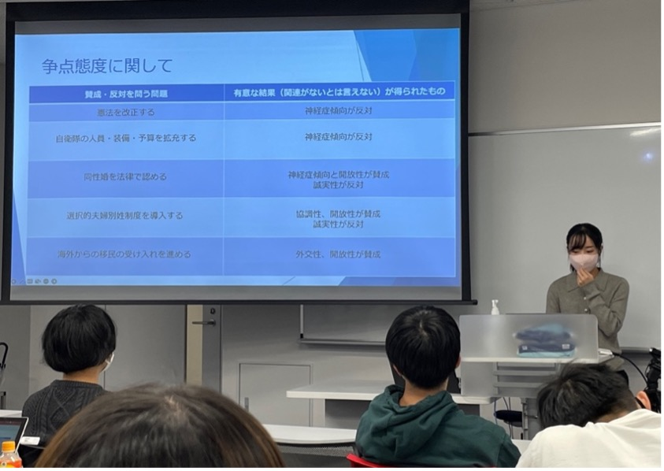

発表中の木村さん

【論文の概要】 人々が持つ政治意識は各個人が置かれたさまざまな環境に起因しているが、メディアや教育等の外部要因だけではなく、個人のパーソナリティが政治への関心度や意見に反映されるのではないかと考えた。そこでビッグファイブ理論を用いてパーソナリティを5つの次元に分類し、政治意識との関連を分析した。結果として、パーソナリティと政治意識には関連があり、また、パーソナリティごとに争点態度の違いが見られることがわかった。

### 「イケメンや美女は選挙で得をするのか」

発表者：  
中山俊輔(政経学部法律政治学科4年)  
政蓮汰(政経学部法律政治学科4年)  
北田貴大(政経学部法律政治学科4年)

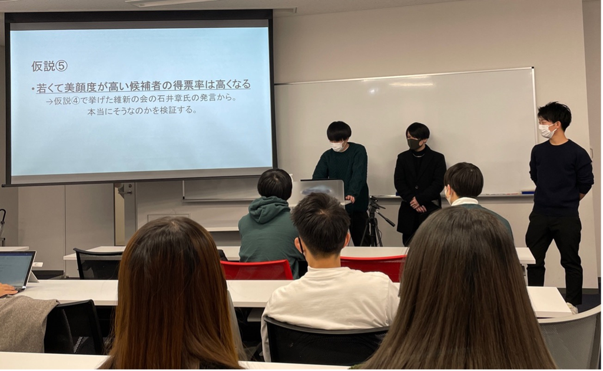

【論文の概要】 本論文では、立候補者の「美顔度」と「得票率」の関係について、2022年に行われた第26回参議院議員通常選挙を調査対象とし、実証分析をしている。私たちは、有権者が投票をする際に、立候補者の「容姿」を基に直感的に判断していると仮定し、各立候補者の「美顔度」を測定し分析を試みた。その結果、統計的に有意とはいえないまでも、「美顔度」が高い候補者ほど「得票率」も高い「傾向がある」ということが分かった。また、自民党所属候補者は「美顔度」が高いほど「得票率」が低くなるという興味深い結果も得られた。

### 「候補者が外交安全保障を重視する要因：2016、2022参議院選挙を事例に」

発表者：粕尾瑞規（早稲田大学社会科学部4年）

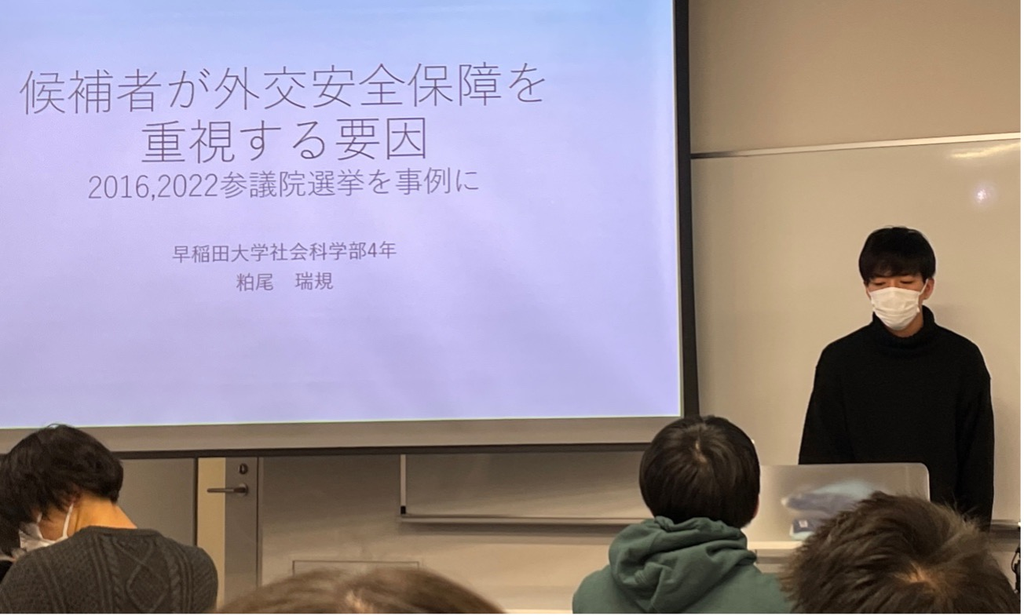

発表中の粕尾さん

【論文の概要】 本報告では、候補者が外交安全保障政策を重視する環境要因の特定を試みた。そして2010年代後半の中国に対する脅威認識の上昇が主要因であるという仮説を得た。従属変数には、外交安保政策を重視するか否かでダミー変数を作り、そこに得票率を掛け選挙区ごとに合計した「重視度」を用いた。分析では自衛隊基地の数や一人あたりGDPなどを独立変数として用いたが、尖閣諸島からの距離が2022年度においてのみ有意となった。またこの「重視度」は西高東低であることから、2017年度以降に西日本を中心に外交安保への意識が地理的な要因によって高まった可能性が指摘できる。

### 「旧統一教会との関係と選挙結果の分析－２０２１年度衆議院総選挙－」

発表者：  
竹内明日香（政経学部法律政治学科４年）  
藤江咲妃（政経学部法律政治学科４年）

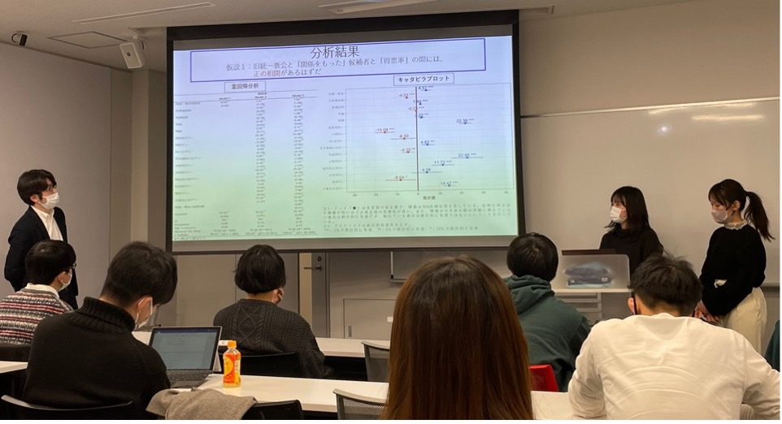

発表中の竹内さんと藤江さん

【論文の概要】 本論文では、2021年度第49回衆議院議員総選挙において、旧統一教会と「関係があった」とされる候補者が実際により多く得票したかどうかを分析している。安倍元首相が銃撃される事件をきっかけとして、旧統一教会と議員との癒着が次々と明らかにされたが、旧統一教会との関係をもったとされる候補者は、そうでない候補者と比べて選挙で優位だったのか？ここでは、当選回数、現職、年齢、政党などの要因を考慮して分析を行った結果、旧統一教会と関係があったとされる候補者のほうが、総選挙でより多くの票を獲得しているという結果が得られた。

### 「安倍元首相暗殺における半旗掲揚と自民党得票率の関係」

発表者：  
大塚真帆（政経学部法律政治学科４年）  
大藤亜有美（政経学部法律政治学科４年）

[figure not shown]

発表中の大塚さんと大藤さん

【論文の概要】 安倍元首相の国葬を実施するにあたり、市によって半旗に関する自治体の対応が異なった。本論文では、市によって半旗を掲揚する・しないという違いあるのはなぜなのか、という問題に取り組んだ。本研究の結果は以下の通りである。

① 参院選比例区で自民党を支持する市ほど、半旗掲揚する確率は高い ② 「20代の人口割合」が大きい市ほど、半旗掲揚する確率は高い ③ 「60歳以上の人口割合」が大きい市ほど、半旗掲揚する確率は高い

### 「Twitter上の世論分析」

発表者：福重 奏（早稲田大学社会科学部3年）

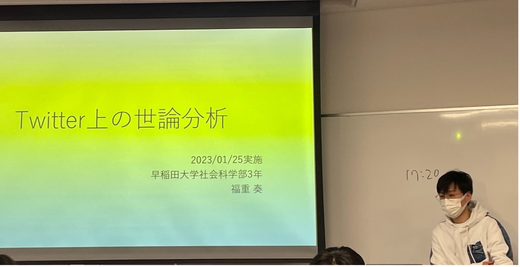

発表中の福重さん

【論文の概要】 Twitterを用いた世論研究が抱える、データの不足による追試の困難さについて指摘し、データを効率的に蓄積した上で利活用する方法を提案した。また、蓄積されたデータを用い、BERT等の機械学習を活用した世論分析の方法についても提案した。

### 参加者から寄せられたコメント

**・拓殖大学 政経学部法律政治学科3年 津田帆稀**  
コロナの影響もあり、このような対面での発表会は初めてでとても迫力がありました。早稲田大学の学生の方の研究で、有権者の性格という視点から政治をみるという研究はとても興味深かったです。自分はプレゼンをしたことがないので良い発表を聞いて参考になりました。

**・拓殖大学 政経学部法律政治学科1年 板野太陽** 論文とは何か、研究とはどのようなものなのかということをを知ることが出来き、良い機会になったと思いました。また先輩方と自分のレベルの差を自覚することができ、少しでも先輩たちに追いつけるように努力したいと思いました。

**・拓殖大学 政経学部法律政治学科4年 藤江咲妃**  
今までオンラインでの参加でしたが、今回対面で早稲田大学と合同ゼミを行い、貴重な経験をさせていただきました。１年間かけてやってきたものをこの合同ゼミを通して成果として見せることができました。また、他大学の学生と議論をし、意見交換をすることによって、多くのことを学び、お互い刺激を与え合うことができたのではないかと思います。

**・拓殖大学 政経学部法律政治学科4年 北田貴大**  
普段の授業内での発表は自分たちがどういう分析をしているかを知ってる人たちに向けての発表でしたが、早稲田大学での発表は普段自分たちが何を分析しているかを知らない人に向けての分析だったので、そういう人たちにも分かってもらえる発表をすることの難しさを感じました。また、早稲田大学の学生もとても興味深い研究をしていて、発表の仕方も上手かったので見習うべき点が多いと感じました。今回の発表会はとても有意義で貴重な経験になったと思います。

**・拓殖大学 政経学部法律政治学科4年 大塚真帆**  
発表会を通して、様々な視点からの研究テーマを学ぶことが出来、とても新鮮で貴重な経験となりました。発表者としてはとても緊張しましたが、発表を通して自分たちの研究をより深く理解することができました。ゼミナールを通して身についた考える力を、今後も様々な面で活用出来たらと思います。

**・拓殖大学 政経学部法律政治学科4年 中山俊輔**  
今回対面での合同ゼミへの参加は初ということもあり、程良い緊張感の中で発表を行うことが出来ました。これまで自分たちで作り上げてきたものを、このような環境で披露したことはとても良い経験であると感じました。また、早稲田生のプレゼンからも刺激を貰うことが出来、充実した時間となりました。

**・拓殖大学 政経学部法律政治学科2年 中條幹人**  
早稲田の発表者の方は投票者の心理を使った論文に取り組み、浅野ゼミとは違った角度から考えていて面白かった。特に最後の三年生の方の発表が印象に残った。Twitterの発言を分析する機械を作ると言った発想もすごいし、話をしてみると、自分が興味のあることに熱心に取り組んでいて刺激を受けた。

**大藤亜有美（政経学部法律政治学科４年）**  
合同ゼミで発表してみて、とても緊張しました。自分たちの研究内容を初めて聞く方々にゼロから説明をするのは大変なことだと改めて感じました。また、早稲田大学の方々がわかりやすく説明をしていたのが印象的でした。質疑応答でもスラスラと質問に回答していて、凄いなと思いました。